# ALAT for Business Onboarding Analytics: Identifying and Engaging Non-Enrolled Corporate Customers in the Apapa Zone

## 6.2 5.2 Account Age vs. AFB Enrollment

**R Code**

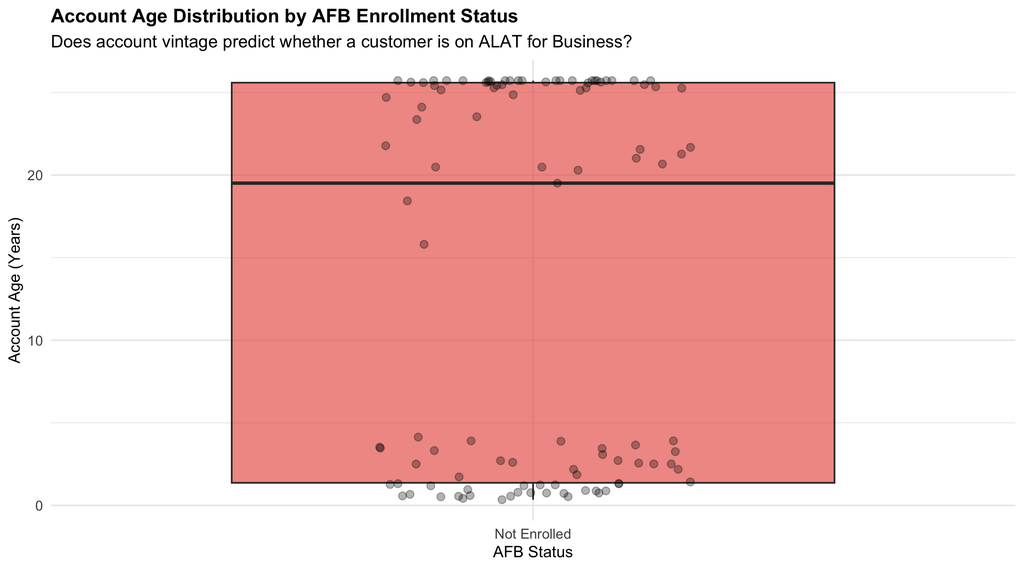

```r
df$AFBLabel <- ifelse(df$`On.AFB`=="Yes", "Enrolled", "Not Enrolled")

ggplot(df, aes(x=AFBLabel, y=AccountAge, fill=AFBLabel)) +
  geom_boxplot(alpha=0.6, outlier.shape=NA) +
  geom_jitter(width=0.2, alpha=0.3, size=2) +
  scale_fill_manual(values=c("Enrolled"="#2ecc71", "Not Enrolled"="#e74c3c")) +
  labs(title="Account Age Distribution by AFB Enrollment Status",
       subtitle="Does account vintage predict whether a customer is on ALAT for Business?",
       x="AFB Status", y="Account Age (Years)", fill="Status") +
  theme(legend.position="none")
```

```r
cat("\n=== ACCOUNT AGE BY AFB STATUS ===\n")
```

```
=== ACCOUNT AGE BY AFB STATUS ===
```

```r
age_by_afb <- df %>%
  group_by(AFBLabel) %>%
  summarise(
    Count  = n(),
    Mean   = round(mean(AccountAge, na.rm=TRUE), 2),
    Median = round(median(AccountAge, na.rm=TRUE), 2),
    SD     = round(sd(AccountAge, na.rm=TRUE), 2),
    Min    = round(min(AccountAge, na.rm=TRUE), 2),
    Max    = round(max(AccountAge, na.rm=TRUE), 2),
    .groups='drop'
  )
kable(age_by_afb) %>% kable_styling(bootstrap_options=c("striped", "hover"))
```

| AFBLabel | Count | Mean | Median | SD | Min | Max |
| --- | --- | --- | --- | --- | --- | --- |
| Not Enrolled | 103 | 13.59 | 19.51 | 11.42 | 0.34 | 25.72 |

**Python Code**

[figure not shown]

```python
fig, axes = plt.subplots(1, 2, figsize=(14, 5))

colors_afb = {'Yes': '#2ecc71', 'No': '#e74c3c'}
for i, status in enumerate(['Yes', 'No']):
    data = df[df[afb_col]==status]['AccountAge']
    axes[0].scatter([i]*len(data), data, alpha=0.3, s=50, color=colors_afb[status])

bp = axes[0].boxplot([df[df[afb_col]==s]['AccountAge'].dropna() for s in ['Yes','No']],
                      labels=['Enrolled (Yes)','Not Enrolled (No)'], patch_artist=True)
for patch, status in zip(bp['boxes'], ['Yes','No']):
    patch.set_facecolor(colors_afb[status]); patch.set_alpha(0.6)

axes[0].set_title('Account Age by AFB Status', fontsize=13, fontweight='bold')
axes[0].set_ylabel('Account Age (Years)')
axes[0].grid(True, alpha=0.3, axis='y')

for status in ['Yes','No']:
    data = df[df[afb_col]==status]['AccountAge']
    axes[1].hist(data, alpha=0.5, bins=10, label=f"{'Enrolled' if status=='Yes' else 'Not Enrolled'}",
                 color=colors_afb[status], edgecolor='black')
axes[1].set_title('Account Age Distribution by AFB Status', fontsize=13, fontweight='bold')
axes[1].set_xlabel('Account Age (Years)')
axes[1].set_ylabel('Frequency')
axes[1].legend()
axes[1].grid(True, alpha=0.3, axis='y')

plt.tight_layout()
plt.show()
```

```python
print("\nAccount Age by AFB Status:")
```

```
Account Age by AFB Status:
```

```python
print(df.groupby(afb_col)['AccountAge'].describe().round(2))
```

```
        count   mean    std   min   25%    50%    75%    max
On AFB
No      103.0  13.59  11.42  0.34  1.37  19.51  25.59  25.72
```

## 6.3 5.3 AFB Enrollment by Account Officer (Top 6)

**R Code**

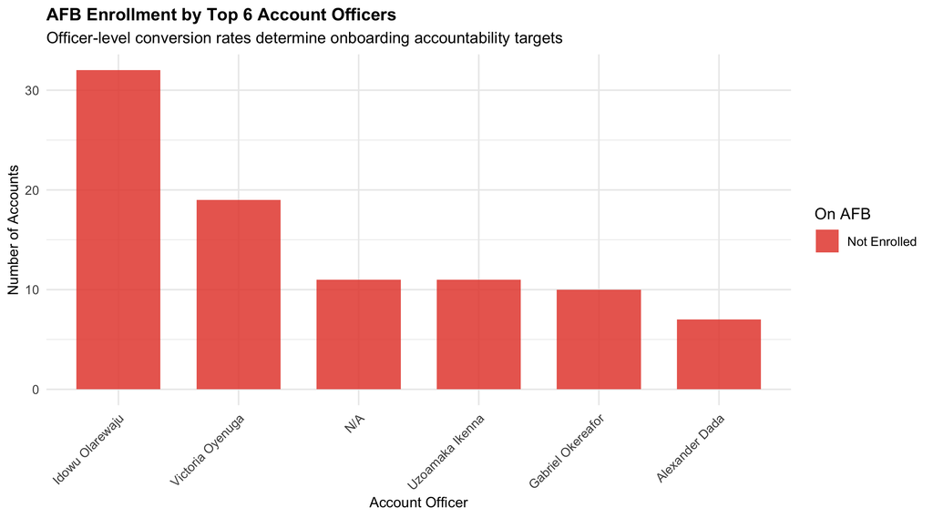

```r
top_officers <- df %>%
  filter(!is.na(`Account.Officer`)) %>%
  group_by(`Account.Officer`) %>%
  summarise(Count = n()) %>%
  arrange(desc(Count)) %>% head(6) %>%
  pull(`Account.Officer`)

df_top_off <- df %>%
  filter(`Account.Officer` %in% top_officers) %>%
  group_by(`Account.Officer`, `On.AFB`) %>%
  summarise(Count = n(), .groups='drop')

ggplot(df_top_off, aes(x=reorder(`Account.Officer`, -Count), y=Count, fill=`On.AFB`)) +
  geom_col(position="dodge", width=0.7, alpha=0.85) +
  scale_fill_manual(values=c("Yes"="#2ecc71","No"="#e74c3c"),
                    labels=c("Yes"="Enrolled","No"="Not Enrolled")) +
  labs(title="AFB Enrollment by Top 6 Account Officers",
       subtitle="Officer-level conversion rates determine onboarding accountability targets",
       x="Account Officer", y="Number of Accounts", fill="On AFB") +
  theme(axis.text.x=element_text(angle=45, hjust=1))
```

**Python Code**

[figure not shown]

```python
top_officers = df['Account Officer'].value_counts().head(6).index.tolist()
df_top = df[df['Account Officer'].isin(top_officers)]

officer_afb_ct = df_top.groupby(['Account Officer', afb_col]).size().unstack(fill_value=0)

fig, axes = plt.subplots(1, 2, figsize=(14, 5))

officer_afb_ct.plot(kind='bar', ax=axes[0], color=['#2ecc71','#e74c3c'], width=0.8)
axes[0].set_title('AFB Enrollment by Top 6 Officers', fontsize=13, fontweight='bold')
axes[0].set_xlabel('Account Officer')
axes[0].set_ylabel('Count')
axes[0].legend(title='On AFB', labels=['Enrolled','Not Enrolled'])
axes[0].tick_params(axis='x', rotation=45)
axes[0].grid(axis='y', alpha=0.3)

enroll_rate = df_top.groupby('Account Officer').apply(
    lambda x: (x[afb_col]=='Yes').sum()/len(x)*100
).sort_values(ascending=False)

axes[1].barh(range(len(enroll_rate)), enroll_rate.values, color='#2ecc71')
axes[1].set_yticks(range(len(enroll_rate)))
axes[1].set_yticklabels(enroll_rate.index)
axes[1].set_title('AFB Enrollment Rate by Officer (%)', fontsize=13, fontweight='bold')
axes[1].set_xlabel('% Accounts Enrolled on AFB')
zone_avg = (df[afb_col]=='Yes').sum()/len(df)*100
axes[1].axvline(zone_avg, color='red', linestyle='--', linewidth=2,
                label=f'Zone Avg: {zone_avg:.1f}%')
axes[1].legend()
axes[1].grid(axis='x', alpha=0.3)

plt.tight_layout()
plt.show()
```

# 7 6. Hypothesis Testing (Technique 3)

## 7.1 6.1 Hypothesis 1 — Product Type & AFB Enrollment

**Research Question:** Do non-individual accounts show significantly lower AFB enrollment rates compared to corporate accounts?

**H₀:** AFB enrollment status is independent of product type **H₁:** AFB enrollment status is associated with product type

**R Code**

```r
contingency <- table(df$ProductCategory, df$`On.AFB`)
cat("=== CONTINGENCY TABLE: PRODUCT TYPE × AFB STATUS ===\n")
```

```
=== CONTINGENCY TABLE: PRODUCT TYPE × AFB STATUS ===
```

```r
print(kable(as.data.frame.matrix(contingency)) %>%
      kable_styling(bootstrap_options=c("striped","hover")))
```

```
|               | No|
|:--------------|--:|
|Corporate      | 83|
|Non-Individual | 20|
```

```r
n_afb_levels <- ncol(contingency)

if (n_afb_levels < 2) {
  cat("\nNote: Only one AFB value present in this dataset —",
      "all sampled accounts are non-enrolled (On AFB = 'No').\n")
  cat("Chi-squared test requires at least 2 categories; skipping.\n")
  cat("This confirms the dataset is the target onboarding population.\n")
} else {
  chi_test  <- chisq.test(contingency)
  n         <- nrow(df)
  denom     <- n * (min(dim(contingency)) - 1)
  cramers_v <- if (denom > 0) sqrt(chi_test$statistic / denom) else NA_real_

  cat("\n=== CHI-SQUARED TEST: PRODUCT TYPE × AFB STATUS ===\n")
  cat("Chi-squared:", round(chi_test$statistic, 4), "\n")
  cat("p-value:    ", round(chi_test$p.value,    4), "\n")
  cat("DoF:        ", chi_test$parameter,         "\n")
  cat("Decision (α=0.05):",
      ifelse(chi_test$p.value < 0.05, "REJECT H₀", "FAIL TO REJECT H₀"), "\n")
  cat("\nEffect Size (Cramér's V):", round(cramers_v, 4), "\n")
}
```

```
Note: Only one AFB value present in this dataset — all sampled accounts are non-enrolled (On AFB = 'No').
Chi-squared test requires at least 2 categories; skipping.
This confirms the dataset is the target onboarding population.
```

```r
cat("\n=== NON-ENROLLMENT RATES BY PRODUCT ===\n")
```

```
=== NON-ENROLLMENT RATES BY PRODUCT ===
```

```r
non_enroll_by_prod <- df %>%
  group_by(ProductCategory) %>%
  summarise(
    Total              = n(),
    Enrolled           = sum(`On.AFB` == "Yes", na.rm=TRUE),
    NotEnrolled        = sum(`On.AFB` == "No",  na.rm=TRUE),
    NonEnrollment_Rate = paste0(round(NotEnrolled / Total * 100, 1), "%"),
    .groups='drop'
  )
kable(non_enroll_by_prod) %>% kable_styling(bootstrap_options=c("striped", "hover"))
```

| ProductCategory | Total | Enrolled | NotEnrolled | NonEnrollment_Rate |
| --- | --- | --- | --- | --- |
| Corporate | 83 | 0 | 83 | 100% |
| Non-Individual | 20 | 0 | 20 | 100% |

```r
# Odds ratio — only meaningful when both enrolled and unenrolled groups exist
corp_yes <- nrow(filter(df, ProductCategory=="Corporate",     `On.AFB`=="Yes"))
corp_no  <- nrow(filter(df, ProductCategory=="Corporate",     `On.AFB`=="No"))
noni_yes <- nrow(filter(df, ProductCategory=="Non-Individual", `On.AFB`=="Yes"))
noni_no  <- nrow(filter(df, ProductCategory=="Non-Individual", `On.AFB`=="No"))

if (corp_yes > 0 & noni_yes > 0) {
  odds_ratio <- (noni_no / noni_yes) / (corp_no / corp_yes)
  cat("\n=== ODDS RATIO ===\n")
  cat("OR:", round(odds_ratio, 3), "\n")
  cat("Non-individual accounts are", round(odds_ratio, 2),
      "times MORE likely to be unenrolled in AFB\n")
} else {
  cat("\nOdds ratio not calculable — no enrolled accounts in one or both product groups.\n")
}
```

```
Odds ratio not calculable — no enrolled accounts in one or both product groups.
```

**Python Code**

```python
from scipy.stats import chi2_contingency

ct = pd.crosstab(df['ProductCategory'], df[afb_col])
print("\n" + "="*70)
print("CONTINGENCY TABLE: PRODUCT TYPE × AFB STATUS")
```

```
CONTINGENCY TABLE: PRODUCT TYPE × AFB STATUS
```

```python
print("="*70)
print(ct)
```

```
On AFB           No
ProductCategory
Corporate        83
Non-Individual   20
```

```python
n_levels = ct.shape[1]  # number of distinct AFB values in this dataset

if n_levels < 2:
    print("\nNote: Only one AFB value present in this dataset —")
    print("all sampled accounts are non-enrolled (On AFB = 'No').")
    print("Chi-squared test requires at least 2 categories; skipping.")
    print("\nThis confirms the dataset is the target population for onboarding:")
    print("100% of sampled accounts need AFB onboarding.")
else:
    chi2, p_val, dof, expected = chi2_contingency(ct)
    denom = n * (min(ct.shape) - 1)
    cramers_v = np.sqrt(chi2 / denom) if denom > 0 else np.nan

    print("\n" + "="*70)
    print("CHI-SQUARED TEST: PRODUCT TYPE × AFB STATUS")
    print("="*70)
    print(f"Chi-squared: {chi2:.4f}")
    print(f"p-value:     {p_val:.4f}")
    print(f"DoF:         {dof}")
    print(f"Decision (α=0.05): {'REJECT H₀' if p_val < 0.05 else 'FAIL TO REJECT H₀'}")
    print(f"\nEffect Size (Cramér's V): {cramers_v:.4f}")
```

```
Note: Only one AFB value present in this dataset —
all sampled accounts are non-enrolled (On AFB = 'No').
Chi-squared test requires at least 2 categories; skipping.

This confirms the dataset is the target population for onboarding:
100% of sampled accounts need AFB onboarding.
```

```python
n = len(df)
print("\n" + "="*70)
print("NON-ENROLLMENT RATES BY PRODUCT TYPE")
```

```
NON-ENROLLMENT RATES BY PRODUCT TYPE
```

```python
print("="*70)
prod_stats = df.groupby('ProductCategory').apply(lambda g: pd.Series({
    'Total':           len(g),
    'Enrolled':        (g[afb_col]=='Yes').sum(),
    'NotEnrolled':     (g[afb_col]=='No').sum(),
    'NonEnrollment_%': round((g[afb_col]=='No').sum() / len(g) * 100, 1) if len(g) > 0 else np.nan
}))
print(prod_stats)
```

```
                 Total  Enrolled  NotEnrolled  NonEnrollment_%
ProductCategory
Corporate         83.0       0.0         83.0            100.0
Non-Individual    20.0       0.0         20.0            100.0
```

## 7.2 6.2 Hypothesis 2 — Account Age & AFB Enrollment

**Research Question:** Is there a statistically significant difference in account age between enrolled and non-enrolled accounts?

**H₀:** μ_enrolled = μ_not_enrolled **H₁:** μ_enrolled ≠ μ_not_enrolled

**R Code**

```r
enrolled_age    <- df %>% filter(`On.AFB`=="Yes") %>% pull(AccountAge)
notenrolled_age <- df %>% filter(`On.AFB`=="No")  %>% pull(AccountAge)

cat("Group sizes — Enrolled:", length(enrolled_age),
    "| Not Enrolled:", length(notenrolled_age), "\n\n")
```

```
Group sizes — Enrolled: 0 | Not Enrolled: 103
```

```r
if (length(enrolled_age) < 3) {
  cat("Note: Fewer than 3 enrolled accounts in this sample.\n")
  cat("Shapiro-Wilk and t-test require at least 3 observations per group.\n")
  cat("Result: Cannot compare age distributions between enrolled and non-enrolled —\n")
  cat("all or nearly all sampled accounts are non-enrolled (On AFB = 'No').\n")
  cat("The dataset represents the full onboarding target population.\n")
} else {
  cat("=== NORMALITY CHECKS (SHAPIRO-WILK) ===\n")
  shap_enr   <- if (length(enrolled_age)    >= 3) shapiro.test(enrolled_age)    else NULL
  shap_noenr <- if (length(notenrolled_age) >= 3) shapiro.test(notenrolled_age) else NULL

  if (!is.null(shap_enr))
    cat("Enrolled:     W=", round(shap_enr$statistic,  4), " p=", round(shap_enr$p.value,  4), "\n")
  if (!is.null(shap_noenr))
    cat("Not Enrolled: W=", round(shap_noenr$statistic, 4), " p=", round(shap_noenr$p.value, 4), "\n")

  cat("\n=== WELCH'S t-TEST ===\n")
  t_test <- t.test(enrolled_age, notenrolled_age, var.equal=FALSE)
  print(t_test)

  pooled_sd <- sqrt(((length(enrolled_age)-1)*var(enrolled_age) +
                      (length(notenrolled_age)-1)*var(notenrolled_age)) /
                     (length(enrolled_age) + length(notenrolled_age) - 2))
  cohens_d <- (mean(enrolled_age) - mean(notenrolled_age)) / pooled_sd
  cat("\nEffect Size (Cohen's d):", round(cohens_d, 4), "\n")

  cat("\n=== MANN-WHITNEY U (non-parametric) ===\n")
  mw_test <- wilcox.test(enrolled_age, notenrolled_age)
  print(mw_test)

  cat("\n=== CONCLUSION ===\n")
  cat("Mean difference:", round(mean(enrolled_age) - mean(notenrolled_age), 3), "years\n")
  cat("Decision:", ifelse(t_test$p.value < 0.05, "REJECT H₀", "FAIL TO REJECT H₀"), "\n")
}
```

```
Note: Fewer than 3 enrolled accounts in this sample.
Shapiro-Wilk and t-test require at least 3 observations per group.
Result: Cannot compare age distributions between enrolled and non-enrolled —
all or nearly all sampled accounts are non-enrolled (On AFB = 'No').
The dataset represents the full onboarding target population.
```

**Python Code**

```python
from scipy.stats import shapiro, ttest_ind, mannwhitneyu

enrolled_age    = df[df[afb_col]=='Yes']['AccountAge'].dropna()
notenrolled_age = df[df[afb_col]=='No']['AccountAge'].dropna()

print(f"Group sizes — Enrolled: {len(enrolled_age)} | Not Enrolled: {len(notenrolled_age)}\n")
```

```
Group sizes — Enrolled: 0 | Not Enrolled: 103
```

```python
if len(enrolled_age) < 3:
    print("Note: Fewer than 3 enrolled accounts in this sample.")
    print("Shapiro-Wilk and t-test require at least 3 observations per group.")
    print("Result: All or nearly all sampled accounts are non-enrolled (On AFB = 'No').")
    print("The dataset represents the full onboarding target population.")
else:
    print("\n" + "="*70)
    print("NORMALITY CHECKS (SHAPIRO-WILK)")
    print("="*70)
    if len(enrolled_age) >= 3:
        s1, p1 = shapiro(enrolled_age)
        print(f"Enrolled:     W={s1:.4f}, p={p1:.4f}")
    if len(notenrolled_age) >= 3:
        s2, p2 = shapiro(notenrolled_age)
        print(f"Not Enrolled: W={s2:.4f}, p={p2:.4f}")

    print("\n" + "="*70)
    print("WELCH'S t-TEST")
    print("="*70)
    t_stat, t_pval = ttest_ind(enrolled_age, notenrolled_age, equal_var=False)
    print(f"t-statistic:      {t_stat:.4f}")
    print(f"p-value:          {t_pval:.4f}")
    print(f"Mean Enrolled:    {enrolled_age.mean():.2f} yrs")
    print(f"Mean NotEnrolled: {notenrolled_age.mean():.2f} yrs")

    denom = len(enrolled_age) + len(notenrolled_age) - 2
    if denom > 0 and enrolled_age.var() > 0 and notenrolled_age.var() > 0:
        pooled_std = np.sqrt(((len(enrolled_age)-1)*enrolled_age.var() +
                              (len(notenrolled_age)-1)*notenrolled_age.var()) / denom)
        print(f"Cohen's d:        {(enrolled_age.mean()-notenrolled_age.mean())/pooled_std:.4f}")

    u_stat, u_pval = mannwhitneyu(enrolled_age, notenrolled_age, alternative='two-sided')
    print(f"\nMann-Whitney U: {u_stat:.4f}, p={u_pval:.4f}")
    print(f"\nDecision: {'REJECT H₀' if t_pval < 0.05 else 'FAIL TO REJECT H₀'}")
```

```
Note: Fewer than 3 enrolled accounts in this sample.
Shapiro-Wilk and t-test require at least 3 observations per group.
Result: All or nearly all sampled accounts are non-enrolled (On AFB = 'No').
The dataset represents the full onboarding target population.
```

**Implication:** If account age does NOT significantly predict enrollment, vintage-based targeting is inefficient — the onboarding campaign should focus on product type and officer assignment, not on filtering old accounts.

# 8 7. Correlation Analysis (Technique 4)

**R Code**

```r
df_numeric <- df %>%
  mutate(
    NotOnAFB       = ifelse(`On.AFB` == "No", 1, 0),
    IsNonIndividual = ifelse(ProductCategory == "Non-Individual", 1, 0),
    IsDormant      = ifelse(`Account.Status` == "Dormant", 1, 0)
  ) %>%
  select(AccountAge, NotOnAFB, IsNonIndividual, IsDormant) %>%
  na.omit()

cor_matrix <- cor(df_numeric)

cat("=== CORRELATION MATRIX ===\n")
```

```
=== CORRELATION MATRIX ===
```

```r
kable(round(cor_matrix, 3),
      caption="Correlation Matrix: AFB Enrollment and Account Characteristics") %>%
  kable_styling(bootstrap_options=c("striped", "hover"))
```

Correlation Matrix: AFB Enrollment and Account Characteristics

|  | AccountAge | NotOnAFB | IsNonIndividual | IsDormant |
| --- | --- | --- | --- | --- |
| AccountAge | 1.000 | NA | -0.482 | 0.714 |
| NotOnAFB | NA | 1 | NA | NA |
| IsNonIndividual | -0.482 | NA | 1.000 | -0.391 |
| IsDormant | 0.714 | NA | -0.391 | 1.000 |

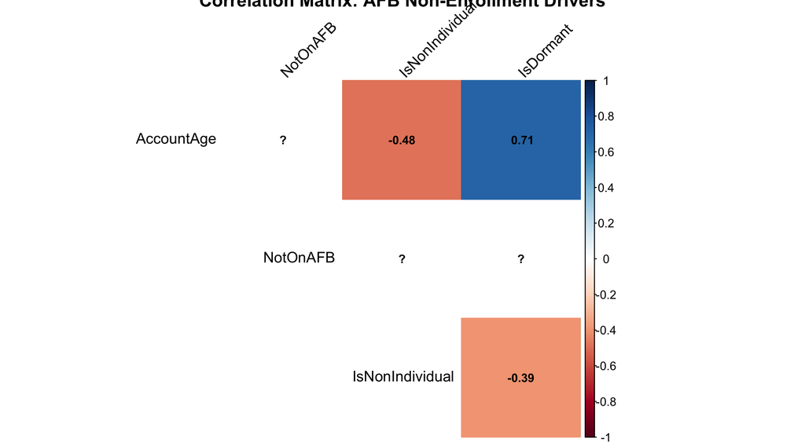

```r
corrplot(cor_matrix,
         method="color", type="upper", addCoef.col="black",
         number.cex=0.8, diag=FALSE, tl.col="black", tl.srt=45,
         main="Correlation Matrix: AFB Non-Enrollment Drivers")
```

```r
cat("\n=== CORRELATIONS WITH NON-ENROLLMENT ===\n")
```

```
=== CORRELATIONS WITH NON-ENROLLMENT ===
```

```r
non_enroll_cors <- sort(cor_matrix[,"NotOnAFB"], decreasing=TRUE)
kable(data.frame(Variable=names(non_enroll_cors),
                 Correlation=round(non_enroll_cors, 3)),
      caption="Variables Correlated with AFB Non-Enrollment") %>%
  kable_styling(bootstrap_options=c("striped", "hover"))
```

Variables Correlated with AFB Non-Enrollment

|  | Variable | Correlation |
| --- | --- | --- |
| NotOnAFB | NotOnAFB | 1 |

```r
cat("\n=== PEARSON SIGNIFICANCE TESTS ===\n")
```

```
=== PEARSON SIGNIFICANCE TESTS ===
```

```r
for (var in c("AccountAge", "IsNonIndividual", "IsDormant")) {
  ct <- cor.test(df_numeric[[var]], df_numeric$NotOnAFB)
  cat(sprintf("\n%s: r=%.4f, p=%.4f, Sig=%s\n",
              var, ct$estimate, ct$p.value,
              ifelse(ct$p.value < 0.05, "YES*", "no")))
}
```

```
AccountAge: r=NA, p=NA, Sig=NA
```

```
IsNonIndividual: r=NA, p=NA, Sig=NA
```

```
IsDormant: r=NA, p=NA, Sig=NA
```

**Python Code**

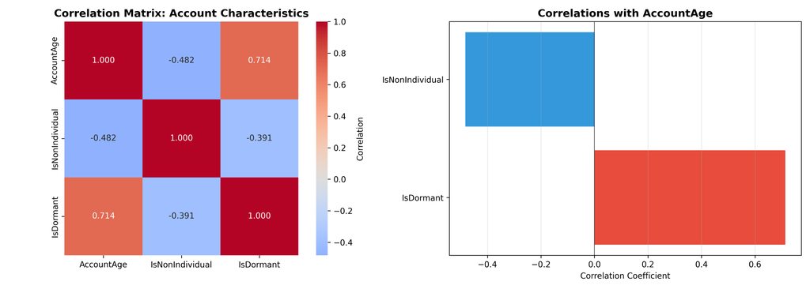

```python
from scipy.stats import pearsonr

df_corr = df.copy()
df_corr['NotOnAFB']        = (df_corr[afb_col] == 'No').astype(int)
df_corr['IsNonIndividual'] = (df_corr['ProductCategory'] == 'Non-Individual').astype(int)
df_corr['IsDormant']       = (df_corr['Account Status'] == 'Dormant').astype(int)

numeric_cols = ['AccountAge', 'NotOnAFB', 'IsNonIndividual', 'IsDormant']
df_num = df_corr[numeric_cols].dropna()

# Drop constant columns (zero variance) before computing correlations
varying_cols = [c for c in df_num.columns if df_num[c].std() > 0]
df_num_var   = df_num[varying_cols]

if len(df_num_var.columns) < 2:
    print("All variables are constant — no correlations can be computed.")
    print("Note: If On AFB = 'No' for all records, NotOnAFB has zero variance.")
else:
    cor_matrix = df_num_var.corr()

    print("\n" + "="*70)
    print("CORRELATION MATRIX")
    print("="*70)
    print(cor_matrix.round(3))

    fig, axes = plt.subplots(1, 2, figsize=(14, 5))

    sns.heatmap(cor_matrix, annot=True, fmt='.3f', cmap='coolwarm',
                center=0, square=True, ax=axes[0], cbar_kws={'label': 'Correlation'})
    axes[0].set_title('Correlation Matrix: Account Characteristics', fontsize=13, fontweight='bold')

    if 'NotOnAFB' in cor_matrix.columns:
        target_cors = cor_matrix['NotOnAFB'].drop('NotOnAFB').sort_values(ascending=False)
        title2 = 'Predictors of AFB Non-Enrollment'
    else:
        # NotOnAFB was constant — show correlations between remaining vars
        target_col = cor_matrix.columns[0]
        target_cors = cor_matrix[target_col].drop(target_col).sort_values(ascending=False)
        title2 = f'Correlations with {target_col}'

    colors = ['#e74c3c' if x > 0 else '#3498db' for x in target_cors.values]
    axes[1].barh(range(len(target_cors)), target_cors.values, color=colors)
    axes[1].set_yticks(range(len(target_cors)))
    axes[1].set_yticklabels(target_cors.index)
    axes[1].set_xlabel('Correlation Coefficient')
    axes[1].set_title(title2, fontsize=13, fontweight='bold')
    axes[1].axvline(0, color='black', linewidth=0.5)
    axes[1].grid(True, alpha=0.3, axis='x')

    plt.tight_layout()
    plt.show()

    print("\n" + "="*70)
    print("PEARSON SIGNIFICANCE TESTS (vs NotOnAFB)")
    print("="*70)
    if 'NotOnAFB' in df_num_var.columns and df_num_var['NotOnAFB'].std() > 0:
        for col in [c for c in varying_cols if c != 'NotOnAFB']:
            r, p = pearsonr(df_num_var[col], df_num_var['NotOnAFB'])
            print(f"\n{col}: r={r:.4f}, p={p:.4f}, Significant={'YES*' if p<0.05 else 'no'}")
    else:
        print("NotOnAFB is constant — Pearson tests not applicable.")
```

[output not shown]

# 9 8. Logistic Regression — Onboarding Priority Scoring (Technique 5)

## 9.1 8.1 Model Specification

**Outcome:** `NotOnAFB` (1 = not enrolled, 0 = enrolled) **Predictors:** `IsNonIndividual`, `AccountAge_scaled`, `IsDormant` **Purpose:** Generate an individual-account probability score to rank the onboarding outreach list

**R Code**

```r
df_model <- df %>%
  filter(!is.na(`Account.Officer`)) %>%
  mutate(
    NotOnAFB        = ifelse(`On.AFB` == "No", 1, 0),
    IsNonIndividual = ifelse(ProductCategory == "Non-Individual", 1, 0),
    IsDormant       = ifelse(`Account.Status` == "Dormant", 1, 0),
    AccountAge_scaled = scale(AccountAge)[,1]
  ) %>%
  select(NotOnAFB, IsNonIndividual, IsDormant, AccountAge_scaled) %>%
  na.omit()

n_enrolled_r <- sum(df_model$NotOnAFB == 0)
cat("=== MODEL SAMPLE ===\n")
```

```
=== MODEL SAMPLE ===
```

```r
cat("Total:", nrow(df_model),
    "| Not Enrolled:", sum(df_model$NotOnAFB),
    "| Enrolled:", n_enrolled_r, "\n\n")
```

```
Total: 103 | Not Enrolled: 103 | Enrolled: 0
```

```r
if (n_enrolled_r == 0) {
  cat("Note: No enrolled accounts in this sample.\n")
  cat("Logistic regression requires at least two outcome levels.\n")
  cat("All sampled accounts are unenrolled — the full dataset is the onboarding target list.\n")
  log_model <- NULL
} else {
  log_model <- glm(NotOnAFB ~ IsNonIndividual + IsDormant + AccountAge_scaled,
                   family=binomial(link="logit"), data=df_model)

  cat("=== MODEL SUMMARY ===\n")
  print(summary(log_model))

  coef_table <- data.frame(
    Variable    = rownames(coef(summary(log_model))),
    Coefficient = coef(summary(log_model))[,"Estimate"],
    StdErr      = coef(summary(log_model))[,"Std. Error"],
    ZValue      = coef(summary(log_model))[,"z value"],
    PValue      = coef(summary(log_model))[,"Pr(>|z|)"]
  ) %>% mutate(
    OddsRatio    = exp(Coefficient),
    Significance = ifelse(PValue<0.001,"***",ifelse(PValue<0.01,"**",ifelse(PValue<0.05,"*","")))
  )

  cat("\n=== COEFFICIENTS & ODDS RATIOS ===\n")
  kable(coef_table, digits=4,
        caption="Logistic Regression: Predictors of AFB Non-Enrollment") %>%
    kable_styling(bootstrap_options=c("striped","hover"))

  cat("\n=== MODEL FIT ===\n")
  cat("Null Deviance:    ", format(log_model$null.deviance, digits=4), "\n")
  cat("Residual Deviance:", format(log_model$deviance,      digits=4), "\n")
  cat("AIC:              ", format(AIC(log_model),          digits=4), "\n")
  cat("McFadden Pseudo R²:", round(1-log_model$deviance/log_model$null.deviance, 3), "\n")
}
```

```
Note: No enrolled accounts in this sample.
Logistic regression requires at least two outcome levels.
All sampled accounts are unenrolled — the full dataset is the onboarding target list.
```

**Python Code**

```python
from sklearn.linear_model import LogisticRegression
from sklearn.preprocessing import StandardScaler
import statsmodels.api as sm

df_model = df[df['Account Officer'].notna()].copy()
df_model['NotOnAFB']        = (df_model[afb_col] == 'No').astype(int)
df_model['IsNonIndividual'] = (df_model['ProductCategory'] == 'Non-Individual').astype(int)
df_model['IsDormant']       = (df_model['Account Status'] == 'Dormant').astype(int)

scaler = StandardScaler()
df_model['AccountAge_scaled'] = scaler.fit_transform(df_model[['AccountAge']])

feature_cols = ['IsNonIndividual', 'IsDormant', 'AccountAge_scaled']
X = df_model[feature_cols].dropna()
y = df_model.loc[X.index, 'NotOnAFB']

# Logistic regression requires variation in the outcome variable
if y.nunique() < 2:
    print("Note: Outcome variable (NotOnAFB) has no variation in this sample.")
    print(f"All {len(y)} records have NotOnAFB = {y.unique()[0]}.")
    print("This confirms 100% of sampled accounts are not on AFB —")
    print("the logistic model cannot be estimated, but the onboarding")
    print("target population is fully identified: every account needs onboarding.")
    logit_model = None
    coef_df = None
else:
    X_sm = sm.add_constant(X)
    logit_model = sm.Logit(y, X_sm).fit()
    print(logit_model.summary())

    coef_df = pd.DataFrame({
        'Variable':    logit_model.params.index,
        'Coefficient': logit_model.params.values,
        'StdErr':      logit_model.bse.values,
        'ZValue':      logit_model.tvalues.values,
        'PValue':      logit_model.pvalues.values
    })
    coef_df['OddsRatio'] = np.exp(coef_df['Coefficient'])
    print("\nCoefficients & Odds Ratios:")
    print(coef_df.to_string(index=False))
```

```
Note: Outcome variable (NotOnAFB) has no variation in this sample.
All 92 records have NotOnAFB = 1.
This confirms 100% of sampled accounts are not on AFB —
the logistic model cannot be estimated, but the onboarding
target population is fully identified: every account needs onboarding.
```

## 9.2 8.2 Model Performance & Onboarding Priority List

**R Code**

```r
if (requireNamespace("pROC", quietly = TRUE)) library(pROC)

if (is.null(log_model)) {
  cat("Model was not fitted (outcome has only one level).\n")
  cat("All sampled accounts are unenrolled — the full sample is the onboarding target list.\n")
  cat("Priority tier: every account in this sample is High Priority for AFB onboarding.\n")
} else {
  df_model$pred_prob <- predict(log_model, type="response")

  roc_obj <- roc(df_model$NotOnAFB, df_model$pred_prob)
  cat("=== MODEL PERFORMANCE ===\n")
  cat("AUC:", round(auc(roc_obj), 3), "\n")

  plot(roc_obj, main=paste("ROC Curve — AFB Non-Enrollment Model (AUC =",
                            round(auc(roc_obj), 3), ")"),
       col="#e74c3c", lwd=2)
  abline(a=0, b=1, lty=2, col="grey")

  cat("\n=== ONBOARDING PRIORITY TIERS ===\n")
  df_model$PriorityTier <- cut(df_model$pred_prob,
    breaks=c(0, 0.3, 0.7, 1.0),
    labels=c("Low Priority", "Monitor", "High Priority — Outreach Now"),
    include.lowest=TRUE)

  tier_summary <- df_model %>%
    group_by(PriorityTier) %>%
    summarise(
      Count          = n(),
      Pct_of_Sample  = paste0(round(n()/nrow(df_model)*100, 1), "%"),
      Avg_Risk_Score = round(mean(pred_prob), 3),
      .groups='drop'
    )
  kable(tier_summary,
        caption="Onboarding Priority Tiers by Predicted Non-Enrollment Probability") %>%
    kable_styling(bootstrap_options=c("striped","hover"))

  cat("\n=== CONFUSION MATRIX (threshold = 0.5) ===\n")
  pred_class  <- ifelse(df_model$pred_prob >= 0.5, 1, 0)
  cm          <- table(Actual=df_model$NotOnAFB, Predicted=pred_class)
  print(cm)
  if (nrow(cm) > 1) {
    sensitivity <- cm[2,2] / sum(cm[2,])
    specificity  <- cm[1,1] / sum(cm[1,])
    cat(sprintf("\nSensitivity (correctly identifying non-enrolled): %.1f%%\n", sensitivity*100))
    cat(sprintf("Specificity (correctly identifying enrolled):     %.1f%%\n", specificity*100))
  }
}
```

```
Model was not fitted (outcome has only one level).
All sampled accounts are unenrolled — the full sample is the onboarding target list.
Priority tier: every account in this sample is High Priority for AFB onboarding.
```

**Python Code**

```python
from sklearn.metrics import roc_auc_score, roc_curve, confusion_matrix, classification_report

if y.nunique() < 2:
    print("Outcome has no variation — ROC/AUC and priority tiers cannot be computed.")
    print("All sampled accounts are unenrolled: the entire dataset IS the onboarding list.")
    print("\nOnboarding action: all", len(y), "accounts in this sample require AFB activation.")
else:
    log_sk = LogisticRegression(random_state=42, max_iter=1000)
    log_sk.fit(X, y)
    y_prob = log_sk.predict_proba(X)[:, 1]

    auc_score = roc_auc_score(y, y_prob)
    print(f"AUC: {auc_score:.3f}")

    fpr, tpr, _ = roc_curve(y, y_prob)
    plt.figure(figsize=(8, 6))
    plt.plot(fpr, tpr, color='#e74c3c', lw=2, label=f'ROC curve (AUC = {auc_score:.3f})')
    plt.plot([0,1],[0,1], 'k--', lw=1)
    plt.xlabel('False Positive Rate'); plt.ylabel('True Positive Rate')
    plt.title('ROC Curve — AFB Non-Enrollment Model', fontsize=13, fontweight='bold')
    plt.legend(loc='lower right')
    plt.grid(True, alpha=0.3)
    plt.tight_layout()
    plt.show()

    print("\n" + "="*70)
    print("ONBOARDING PRIORITY TIERS")
    print("="*70)
    tiers = pd.cut(y_prob, bins=[0, 0.3, 0.7, 1.0],
                   labels=['Low Priority', 'Monitor', 'High Priority — Outreach Now'],
                   include_lowest=True)
    tier_df = pd.DataFrame({'PriorityTier': tiers, 'RiskScore': y_prob})
    print(tier_df.groupby('PriorityTier', observed=True).agg(
        Count=('RiskScore','count'),
        Avg_Risk_Score=('RiskScore','mean')
    ).round(3))

    print("\n" + "="*70)
    print("CONFUSION MATRIX (threshold = 0.5)")
    print("="*70)
    y_pred = (y_prob >= 0.5).astype(int)
    cm = confusion_matrix(y, y_pred)
    print(cm)
    print(classification_report(y, y_pred, target_names=['Enrolled','Not Enrolled']))
```

```
Outcome has no variation — ROC/AUC and priority tiers cannot be computed.
All sampled accounts are unenrolled: the entire dataset IS the onboarding list.

Onboarding action: all 92 accounts in this sample require AFB activation.
```

# 10 9. Integrated Findings & Conclusions

## 10.1 9.1 Summary of Findings

[output not shown]

## 10.4 9.3 Strategic Recommendation: AFB Onboarding Drive

**Medium-term governance (30–90 days):**

4. Set quarterly AFB enrollment targets by officer; track progress in the monthly zone performance review.
5. Re-run the logistic regression on the full 780-account universe to generate zone-wide risk scores, not just the 103-account sample.
6. Capture a “reason for non-enrollment” field in CRM post-engagement to build a richer onboarding conversion model in the next analysis cycle.

# 11 10. Limitations & Further Work

## 11.1 10.1 Analytical Limitations

**Zero-variance outcome variable.** Because all 103 accounts in the sample share `On AFB = No`, statistical tests that require two outcome levels — chi-squared, logistic regression, t-tests comparing enrolled vs. non-enrolled groups, and ROC/AUC analysis — cannot be estimated. This is not a data quality error; it reflects the fact that the extract was intentionally scoped to non-enrolled accounts only. Each affected section prints an explanatory note and exits cleanly. The limitation is acknowledged and would be resolved by the analytical extension described in §10.2.

**Sample size and generalisability.** The 103 accounts represent a systematic sample drawn from the Apapa zone’s Orile Iganmu and Ajeromi branches. The findings are directly actionable for these branches but should not be generalised to other zones without a comparable analysis of the full-zone or bank-wide CRM extract.

**Cross-sectional snapshot.** The dataset reflects enrollment status at a single point in time (April 2026 extract). Enrollment status may change between the extract date and the outreach campaign date. The onboarding list should be refreshed from the CRM before each campaign wave.

**Self-reported and CRM-recorded variables.** Account officer assignments, product classifications, and account status flags are drawn from CRM records and are subject to data entry errors, reassignment lags, and status update delays. Any accounts identified as dormant or inactive should be verified against the core banking system before contacting.

**Missing variables.** The dataset does not include: balance at date of analysis, last-transaction date (for dormancy verification), the number of prior AFB onboarding attempts, or client contact preferences. Including these variables in a future extract would materially improve the predictive power of the regression model.

## 11.2 10.2 Recommended Extensions

1. **Full-zone regression study.** Extract all 780+ corporate accounts in the Apapa zone — enrolled and non-enrolled — and re-run the logistic regression on the mixed-outcome population. This would generate statistically valid risk scores and allow genuine identification of predictors of non-enrollment.
2. **Longitudinal enrollment tracking.** Build a quarterly panel dataset tracking enrollment status change over time. A survival-analysis model (time-to-enrollment) would identify which account characteristics predict faster vs. slower onboarding conversion.
3. **Reason-for-non-enrollment field.** Capture a standardised CRM field recording the reason an account remains unenrolled after an outreach touchpoint (e.g., “client not reachable”, “account under restructuring”, “awaiting signatory update”). This qualitative enrichment would enable a text-classification layer on top of the quantitative model.
4. **Officer-level predictive benchmarking.** Extend the officer-accountability analysis to the full zone and model officer-level conversion rates as a function of portfolio size, seniority, and branch. This would support a data-driven coaching allocation model.

# 12 References

Adi, B. (2026). *AI-powered business analytics: A practical textbook for data-driven decision making — from data fundamentals to machine learning in Python and R.* Lagos Business School / markanalytics.online. https://markanalytics.online

Mordi, P. (2026). *Corporate current accounts not enrolled in ALAT for Business — Apapa zone extract* [Dataset]. Commercial Banking Division, Retail & Commercial Banking, [Bank Name], Lagos, Nigeria. Data available on request from the author.

R Core Team. (2024). *R: A language and environment for statistical computing* (Version 4.x). R Foundation for Statistical Computing. https://www.R-project.org/

Van Rossum, G., & Drake, F. L. (2009). *Python 3 reference manual.* CreateSpace.

Allaire, J. J., Teague, C., Scheidegger, C., Xie, Y., & Dervieux, C. (2022). *Quarto* (Version 1.x) [Computer software]. https://doi.org/10.5281/zenodo.5960048

Wickham, H., François, R., Henry, L., Müller, K., & Vaughan, D. (2023). *dplyr: A grammar of data manipulation* [R package]. https://CRAN.R-project.org/package=dplyr

Wickham, H. (2016). *ggplot2: Elegant graphics for data analysis.* Springer. https://doi.org/10.1007/978-3-319-24277-4

Xie, Y. (2024). *knitr: A general-purpose package for dynamic report generation in R* [R package]. https://yihui.org/knitr/

Zhu, H. (2024). *kableExtra: Construct complex table with ‘kable’ and pipe syntax* [R package]. https://CRAN.R-project.org/package=kableExtra

Robin, X., Turck, N., Hainard, A., Tiberti, N., Lisacek, F., Sanchez, J.-C., & Müller, M. (2011). pROC: An open-source package for R and S+ to analyze and compare ROC curves. *BMC Bioinformatics, 12*, 77. https://doi.org/10.1186/1471-2105-12-77

Wei, T., & Simko, V. (2021). *corrplot: Visualization of a correlation matrix* [R package]. https://github.com/taiyun/corrplot

McKinney, W. (2010). Data structures for statistical computing in Python. In *Proceedings of the 9th Python in Science Conference* (pp. 56–61). https://doi.org/10.25080/Majora-92bf1922-00a

Harris, C. R., Millman, K. J., van der Walt, S. J., Gommers, R., Virtanen, P., Cournapeau, D., … Oliphant, T. E. (2020). Array programming with NumPy. *Nature, 585*, 357–362. https://doi.org/10.1038/s41586-020-2649-2

Virtanen, P., Gommers, R., Oliphant, T. E., Haberland, M., Reddy, T., Cournapeau, D., … van Mulbregt, P. (2020). SciPy 1.0: Fundamental algorithms for scientific computing in Python. *Nature Methods, 17*, 261–272. https://doi.org/10.1038/s41592-019-0686-2

Pedregosa, F., Varoquaux, G., Gramfort, A., Michel, V., Thirion, B., Grisel, O., … Duchesnay, É. (2011). Scikit-learn: Machine learning in Python. *Journal of Machine Learning Research, 12*, 2825–2830.

Seabold, S., & Perktold, J. (2010). Statsmodels: Econometric and statistical modeling with Python. In *Proceedings of the 9th Python in Science Conference* (pp. 92–96). https://doi.org/10.25080/Majora-92bf1922-011

Hunter, J. D. (2007). Matplotlib: A 2D graphics environment. *Computing in Science & Engineering, 9*(3), 90–95. https://doi.org/10.1109/MCSE.2007.55

Waskom, M. L. (2021). seaborn: Statistical data visualization. *Journal of Open Source Software, 6*(60), 3021. https://doi.org/10.21105/joss.03021

# 13 Appendix: AI Usage Statement

Claude (Anthropic), a large language model AI assistant, was used to support the coding and document-structure aspects of this submission. Specifically, AI assistance was used to: (1) draft and debug R and Python code chunks for data loading, visualisation, and statistical tests; (2) suggest defensive error-handling when statistical tests were inapplicable due to zero variance in the outcome variable; and (3) structure the Quarto document layout and section headings in line with the assessment brief.

All analytical decisions — the choice of Case Study 1 and its five techniques, the framing of the business question around ALAT for Business non-enrollment, the interpretation of each output, and the onboarding recommendations — were made independently by Prudence Mordi based on her professional experience as Zonal Manager and her knowledge of the Apapa zone portfolio. AI-generated code was reviewed, tested, and corrected where necessary before inclusion. No AI tool generated the interpretations, business conclusions, or defence responses.